# capstone

Chris Snow

06/11/2016

## Load the raw data

```r
library(tools)

md5 <- md5sum('Coursera-SwiftKey.zip')
if (md5 != 'e0629c64b1747103a7e751b0a30d3858') {
   url <- 'https://d396qusza40orc.cloudfront.net/dsscapstone/dataset/Coursera-SwiftKey.zip'
   download.file(url, destfile = 'Coursera-SwiftKey.zip')
   unzip('Coursera-SwiftKey.zip')

   # free some space on my drive by removing unneeded files
   unlink('./final/de_DE/', recursive = TRUE, force = TRUE)
   unlink('./final/fi_FI/', recursive = TRUE, force = TRUE)
   unlink('./final/ru_RU/', recursive = TRUE, force = TRUE)
}

rm(md5)
```

This is non portable as it requires unix wordcount (wc) utility, however it’s very simple:

```r
print(system('wc ./final/en_US/en_US.blogs.txt', intern = TRUE))
```

```
## [1] "  899288 37334690 210160014 ./final/en_US/en_US.blogs.txt"
```

```r
print(system('wc ./final/en_US/en_US.news.txt', intern = TRUE))
```

```
## [1] " 1010242 34372720 205811889 ./final/en_US/en_US.news.txt"
```

```r
print(system('wc ./final/en_US/en_US.twitter.txt', intern = TRUE))
```

```
## [1] " 2360148 30374206 167105338 ./final/en_US/en_US.twitter.txt"
```

The output from wc is: num_lines, num_words, num_chars

## Load required packages

```r
if(!require(slam)) {
  install.packages("slam",  type="binary")
  library(slam)
}
if(!require(tm)) {
  install.packages("tm")
  library(tm)
}
if(!require(Rgraphviz)) {
  source("http://bioconductor.org/biocLite.R")
  biocLite("Rgraphviz", ask = FALSE)
  library(Rgraphviz)
}
if(!require(wordcloud)) {
  install.packages("wordcloud")
  library(wordcloud)
}
```

## Create the corpus

Limit the number of docs from each source because the full dataset will require too much computing resource to process. A better approach may be to randomly sample lines rather than reading then all.

```r
LIMIT_NUM_DOCS <- 2000
```

```r
## blogs
con <- file('./final/en_US/en_US.blogs.txt')
open(con)
v <- readLines(con, n=LIMIT_NUM_DOCS, skipNul=TRUE)
close(con)

# news
con <- file('./final/en_US/en_US.news.txt')
open(con)
v <- append(v, readLines(con, n=LIMIT_NUM_DOCS, skipNul=TRUE))
close(con)

# twitter
con <- file('./final/en_US/en_US.twitter.txt')
open(con)
v <- append(v, readLines(con, n=LIMIT_NUM_DOCS, skipNul=TRUE))
close(con)

vs <- VectorSource(v)

rm(v, con)
```

```r
bannedWords <- as.list(read.csv(url('http://www.bannedwordlist.com/lists/swearWords.txt'), header = FALSE))
# head(bannedWords)

removeWordsContaining <-
function(x, words)
    UseMethod("removeWordsContaining", x)
removeWordsContaining.character <-
function(x, words)
    gsub(sprintf("(*UCP)\\b[a-zA-Z]*(%s)[a-zA-Z]*\\b",
                 paste(sort(words, decreasing = TRUE), collapse = "|")),
         "", x, perl = TRUE)
removeWordsContaining.PlainTextDocument <-
    content_transformer(removeWordsContaining.character)

blog_corpus <- Corpus(vs, readerControl = list(language="en"))
blog_corpus <- tm_map(blog_corpus, content_transformer(tolower))
blog_corpus <- tm_map(blog_corpus, stripWhitespace)
blog_corpus <- tm_map(blog_corpus, removePunctuation)
blog_corpus <- tm_map(blog_corpus, removeNumbers)

# the most common n-gram models are based on stop words - we don't want to remove them
# blog_corpus <- tm_map(blog_corpus, removeWords, c(stopwords("english")))

# news corpus has some unicode characters that need to be removed
ct <- content_transformer(function(x, pattern) gsub(pattern, "", x))
blog_corpus <- tm_map(blog_corpus, ct, "\u0095")
blog_corpus <- tm_map(blog_corpus, ct, "\u0096")
blog_corpus <- tm_map(blog_corpus, ct, "\u0097")

blog_corpus <- tm_map(blog_corpus, removeWordsContaining, bannedWords$V1)

# remove vs
rm(vs, bannedWords)
```

## Tokenize to plain TermDocumentMatrix

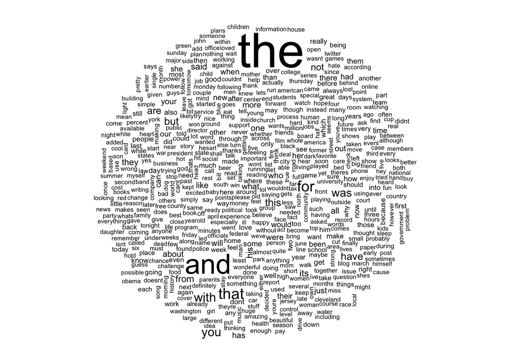

```r
wordcloud(words = blog_corpus, min.freq = 30)
```

```r
rm(LIMIT_NUM_DOCS)
```

```r
tdm <- TermDocumentMatrix(blog_corpus,
                          control = list(removePunctuation = TRUE,
                                         removeNumbers = TRUE,
                                         stopwords = TRUE))
inspect(tdm[1:10, 1:10])
```

```
## <<TermDocumentMatrix (terms: 10, documents: 10)>>
## Non-/sparse entries: 0/100
## Sparsity           : 100%
## Maximal term length: 7
## Weighting          : term frequency (tf)
##
##          Docs
## Terms     1 2 3 4 5 6 7 8 9 10
##   ½in     0 0 0 0 0 0 0 0 0  0
##   aadil   0 0 0 0 0 0 0 0 0  0
##   aaggh   0 0 0 0 0 0 0 0 0  0
##   aaiight 0 0 0 0 0 0 0 0 0  0
##   aaron   0 0 0 0 0 0 0 0 0  0
##   aaronic 0 0 0 0 0 0 0 0 0  0
##   aarons  0 0 0 0 0 0 0 0 0  0
##   aarp    0 0 0 0 0 0 0 0 0  0
##   aasl    0 0 0 0 0 0 0 0 0  0
##   abandon 0 0 0 0 0 0 0 0 0  0
```

```r
terms <- dimnames(tdm[ ,1:50])$Terms
```

```r
inspect(tdm[grep('aadil', terms), 1:10])
```

```
## <<TermDocumentMatrix (terms: 1, documents: 10)>>
## Non-/sparse entries: 0/10
## Sparsity           : 100%
## Maximal term length: 5
## Weighting          : term frequency (tf)
##
##        Docs
## Terms   1 2 3 4 5 6 7 8 9 10
##   aadil 0 0 0 0 0 0 0 0 0  0
```

Verify that bannedWords have been removed:

```r
inspect(tdm[grep('fuck', terms), 1:10])
```

```
## <<TermDocumentMatrix (terms: 0, documents: 10)>>
## Non-/sparse entries: 0/0
## Sparsity           : 100%
## Maximal term length: 0
## Weighting          : term frequency (tf)
##
##       Docs
## Terms  1 2 3 4 5 6 7 8 9 10
```

## Tokenize to ngrams - What are the frequencies of 2-grams and 3-grams in the dataset?

```r
ngramDTM <- function (ngrams) {
  TrigramTokenizer <-
    function(x)
      unlist(lapply(ngrams(words(x), ngrams), paste, collapse = " "), use.names = FALSE)

  datmat <- TermDocumentMatrix(blog_corpus, control = list(tokenize = TrigramTokenizer))

  return(as.matrix(datmat))
}
```

```r
digrams = ngramDTM(2)
digrams[1:5, 1:3]
```

```
##             Docs
## Terms        1 2 3
##   ½ seconds  0 0 0
##   ½in cookie 0 0 0
##   ¼ teaspoon 0 0 0
##   ⅛ teaspoon 0 0 0
##   ¾ th       0 0 0
```

```r
digramsCounts <- rowSums(digrams)
head(as.matrix(digramsCounts))
```

```
##            [,1]
## ½ seconds     1
## ½in cookie    1
## ¼ teaspoon    1
## ⅛ teaspoon    1
## ¾ th          2
## ¾ third       1
```

```r
tail(as.matrix(digramsCounts))
```

```
##                   [,1]
## zutara and           1
## zydeco gatherings    1
## zydeco one           1
## zydeco yall          1
## zz top               1
## それじゃ pardon      1
```

```r
digramsGT10 <- digramsCounts[ digramsCounts > 10 ]
as.matrix (
  digramsGT10[ head( order( digramsGT10, decreasing = T), 25 ) ]
)
```

```
##          [,1]
## of the    793
## in the    745
## to the    376
## on the    337
## for the   330
## to be     325
## and the   244
## at the    230
## in a      226
## with the  211
## from the  177
## it was    173
## and i     162
## is a      157
## of a      156
## i have    147
## i am      144
## it is     144
## with a    144
## that the  139
## i was     134
## one of    131
## going to  127
## for a     125
## as a      121
```

```r
trigrams = ngramDTM(3)
trigramsCounts <- rowSums(trigrams)
trigramsGT10 <- trigramsCounts[ trigramsCounts > 10 ]
as.matrix (
  trigramsGT10[ head( order( trigramsGT10, decreasing = T), 25 ) ]
)
```

```
##                  [,1]
## a lot of           71
## one of the         64
## going to be        32
## it was a           26
## the end of         25
## to be a            25
## a couple of        24
## i want to          24
## be able to         23
## part of the        23
## i dont know        22
## i have a           22
## out of the         22
## some of the        22
## as well as         21
## i had a            21
## thanks for the     20
## the rest of        19
## there is a         19
## is one of          18
## it would be        18
## according to the   17
## as much as         17
## i had to           17
## i have to          17
```

## How many unique words do you need in a frequency sorted dictionary to cover 50% of all word instances in the language? 90%?

This is a sentence to understand how to count word instances and perform a frequency analysis.

- ‘2’ a
- ‘2’ to
- ‘1’ This
- ‘1’ is
- ‘1’ sentence
- ‘1’ understand
- ‘1’ how
- ‘1’ count
- ‘1’ word
- ‘1’ instances
- ‘1’ and
- ‘1’ perform
- ‘1’ frequency
- ‘1’ analysis

```r
temp <- inspect(tdm)
FreqMat <- data.frame(ST = rownames(temp), Freq = rowSums(temp))
row.names(FreqMat) <- NULL
```

```r
FreqMatDF <- as.data.frame(FreqMat)
FreqMatDF <- FreqMatDF[order(FreqMatDF$Freq, decreasing = TRUE), ]
FreqMatDF$cumsum <- cumsum(FreqMatDF$Freq)
totalWords <- sum(FreqMatDF$Freq)
```

50% of corpus is covered by this number of unique words:

```r
print( nrow(FreqMatDF[FreqMatDF$cumsum < (totalWords * 0.5), ]) )
```

```
## [1] 979
```

90% of corpus is covered by this number of unique words:

```r
print( nrow(FreqMatDF[FreqMatDF$cumsum < (totalWords * 0.9), ]) )
```

```
## [1] 10868
```

## Non English words

```r
english_words <- as.vector(FreqMatDF$ST[grepl("^[[:digit:][:alpha:]]+$", FreqMatDF$ST)])
head(english_words)
```

```
## [1] "said" "one"  "will" "like" "just" "can"
```

```r
tail(english_words)
```

```
## [1] "zta"      "zuccotti" "zulfar"   "zuma"     "zumwalt"  "zutara"
```

```r
non_english_words <- as.vector(FreqMatDF$ST[grepl("^[^[:digit:][:alpha:]]+$", FreqMatDF$ST)])
head(non_english_words)
```

```
## [1] "それじゃ"               "ブッダビールが必要だね"
## [3] ""
```

```r
tail(non_english_words)
```

```
## [1] "それじゃ"               "ブッダビールが必要だね"
## [3] ""
```

```r
num_english_words <- length(english_words)
print( num_english_words )
```

```
## [1] 20132
```

```r
num_non_english_words <- length(non_english_words)
print( num_non_english_words )
```

```
## [1] 3
```

Percentage of non-english words

```r
print( num_non_english_words / (num_english_words + num_non_english_words))
```

```
## [1] 0.0001489943
```

## Assignment 1

Instructions

The goal of this project is just to display that you’ve gotten used to working with the data and that you are on track to create your prediction algorithm. Please submit a report on R Pubs (http://rpubs.com/) that explains your exploratory analysis and your goals for the eventual app and algorithm. This document should be concise and explain only the major features of the data you have identified and briefly summarize your plans for creating the prediction algorithm and Shiny app in a way that would be understandable to a non-data scientist manager. You should make use of tables and plots to illustrate important summaries of the data set. The motivation for this project is to: 1. Demonstrate that you’ve downloaded the data and have successfully loaded it in.2. Create a basic report of summary statistics about the data sets.3. Report any interesting findings that you amassed so far.4. Get feedback on your plans for creating a prediction algorithm and Shiny app.

Review criteria:

- Does the link lead to an HTML page describing the exploratory analysis of the training data set?
- Has the data scientist done basic summaries of the three files? Word counts, line counts and basic data tables?
- Has the data scientist made basic plots, such as histograms to illustrate features of the data?
- Was the report written in a brief, concise style, in a way that a non-data scientist manager could appreciate?

## Tasks

Task

1. Exploratory analysis - perform a thorough exploratory analysis of the data, understanding the distribution of words and relationship between the words in the corpora.
2. Understand frequencies of words and word pairs - build figures and tables to understand variation in the frequencies of words and word pairs in the data.

Questions

1. Some words are more frequent than others - what are the distributions of word frequencies?
2. What are the frequencies of 2-grams and 3-grams in the dataset?
3. How many unique words do you need in a frequency sorted dictionary to cover 50% of all word instances in the language? 90%?
4. How do you evaluate how many of the words come from foreign languages?
5. Can you think of a way to increase the coverage – identifying words that may not be in the corpora or using a smaller number of words in the dictionary to cover the same number of phrases?

Task

1. Build basic n-gram model - using the exploratory analysis you performed, build a basic n-gram model for predicting the next word based on the previous 1, 2, or 3 words.
2. Build a model to handle unseen n-grams - in some cases people will want to type a combination of words that does not appear in the corpora. Build a model to handle cases where a particular n-gram isn’t observed.

Questions

1. How can you efficiently store an n-gram model (think Markov Chains)?
2. How can you use the knowledge about word frequencies to make your model smaller and more efficient?
3. How many parameters do you need (i.e. how big is n in your n-gram model)?
4. Can you think of simple ways to “smooth” the probabilities (think about giving all n-grams a non-zero probability even if they aren’t observed in the data) ?
5. How do you evaluate whether your model is any good?
6. How can you use backoff models to estimate the probability of unobserved n-grams?

Task

1. Build a predictive model based on the previous data modeling steps - you may combine the models in any way you think is appropriate.
2. Evaluate the model for efficiency and accuracy - use timing software to evaluate the computational complexity of your model. Evaluate the model accuracy using different metrics like perplexity, accuracy at the first word, second word, and third word.

Questions

1. How does the model perform for different choices of the parameters and size of the model?
2. How much does the model slow down for the performance you gain?
3. Does perplexity correlate with the other measures of accuracy?
4. Can you reduce the size of the model (number of parameters) without reducing performance?

Task

1. Explore new models and data to improve your predictive model.
2. Evaluate your new predictions on both accuracy and efficiency.

Questions

1. What are some alternative data sets you could consider using?
2. What are ways in which the n-gram model may be inefficient?
3. What are the most commonly missed n-grams? Can you think of a reason why they would be missed and fix that?
4. What are some other things that other people have tried to improve their model?
5. Can you estimate how uncertain you are about the words you are predicting?

Task

1. Create a data product to show off your prediction algorithm You should create a Shiny app that accepts an n-gram and predicts the next word.

Question

1. What are the most interesting ways you could show off your algorithm?
2. Are there any data visualizations you think might be helpful (look at the Swiftkey data dashboard if you have it loaded on your phone)?
3. How should you document the use of your data product (separately from how you created it) so that others can rapidly deploy your algorithm?

Tips

Consider the size of the predictive model you have developed. You may have to sacrifice some accuracy to have a fast enough/small enough model to load into Shiny.

Task

Create a slide deck promoting your product. Write 5 slides using RStudio Presenter explaining your product and why it is awesome!

Questions

1. How can you briefly explain how your predictive model works?
2. How can you succinctly quantitatively summarize the performance of your prediction algorithm?
3. How can you show the user how the product works?